# Introduction

**Dataset:** [eCommerce purchase history from electronics store](https://www.kaggle.com/datasets/mkechinov/ecommerce-purchase-history-from-electronics-store)

In today's competitive online landscape, ecommerce stores are facing the challenge of decreasing profit margins due to rising advertisement costs and difficulty in acquiring new customers. After all, as more and more competitors enter the market, the cost of online advertisement skyrockets, thus making it harder and more costly for ecommerce brands to acquire new customers and ultimately squeezing their profit margins. Now, one possible solution to this problem is to focus on generating repeat orders from already existing customers. After all, acquiring a new customer is way more costly tha getting a current customer to buy again (Reichheld & Schefter, 2000). To achieve this, ecommerce brands can analyze their customers' purchasing behavior and come up with targeted upselling and cross-selling recommendations. This would make advertising campaigns more effective and drive profitability upwards.

In this data mining project, we aim to look for purchasing patterns in the behavior of the customers of a ecommerce electronics store. Our goal is to help the company generate more repeat purchases by providing personalized product recommendations to their customers. We plan to achieve this by analyzing purchasing and website usage data to identify patterns that can possibly lead to personalized recommendations. By doing so, we aim to provide ecommerce stores with actionable insights that can drive sales, improve customer repeat purchase, and ultimately increase revenue.

However, to make this project applicable to real-world scenarios, we must consider certain factors. For instance, most remarketing campaigns are run through social media platforms, such as Instagram or YouTube, which have limited and costly ad space. Therefore, we cannot generate many recommendations, and we must focus on generating recommendations that are most likely to be effective from a return on investment perspective. Moreover, considering the human-in-the-loop nature of these ad platforms, explainability is a must for our project. So, by providing clear and explainable insights into the behavior of our customer base, we hope to find out into why certain upselling strategies could work and how they can be improved.

In summary, our hope is that our findings will help ecommerce stores improve customer retention, increase revenue, and ultimately become more competitive in the online marketplace by leveraging data mining techniques.

# Data Loading & Data Preprocessing

## Imports

Before loading our ecommerce dataset and start squeezing useful insights from it, we must first make the necessary Python imports that are required to work with the data.

```python
import pandas as pd
import numpy as np
import matplotlib.pyplot as plt
import seaborn as sns


# Change plt figure size to (15,8)
plt.rcParams['figure.figsize'] = (15,8)

# silence kernel warnings
import warnings
warnings.filterwarnings('ignore')
```

## Data Loading

Let's begin our project by loading the eCommerce purchase history dataset and analyzing how it is structured.

```python
df = pd.read_csv('kz.csv')

# Show the number of rows and the number of columns
print(f'The number of rows is {df.shape[0]} and the number of columns is {df.shape[1]}')

df.sample(4)
```

```
The number of rows is 2633521 and the number of columns is 8
```

|  | event_time | order_id | product_id | category_id | category_code | brand | price | user_id |
| --- | --- | --- | --- | --- | --- | --- | --- | --- |
| 493804 | 2020-02-14 14:36:13 UTC | 2348795565682197246 | 1515966223509104165 | 2.268105e+18 | electronics.smartphone | huawei | 416.64 | NaN |
| 2614623 | 2020-11-18 09:53:16 UTC | 2388440981134683171 | 1515966223509629842 | 2.268105e+18 | NaN | neo | 4.14 | 1.515916e+18 |
| 1953300 | 2020-08-22 23:26:48 UTC | 2382409907417645989 | 1515966223509629842 | 2.268105e+18 | NaN | neo | 4.14 | 1.515916e+18 |
| 2557839 | 2020-11-01 09:29:24 UTC | 2388440981134649315 | 1515966223509336343 | 2.268105e+18 | construction.tools.screw | ava | 3.45 | 1.515916e+18 |

As we can see, the dataset only has 8 features, which thankfully isn't that many. This will make our analysis going forward a lot easier since the dataset itself has only kept the essential columns for us to analyze. However, the dataset has a lot of rows, with each row representing a purchased product of this store. Therefore, we will have to pay close attention to how we preprocess the data in order to reduce its memory and avoid potential memory leakage problems.

Thankfully, most of these issues can be addressed with just a few preprocessing steps. For instance, let's start by reducing the event_time column to 'yyyy-mm-dd' format since the timezone information and timestamp details will not be useful for our analysis going forward.

```python
df = df.assign(event_time = lambda x: x['event_time'].apply(lambda x: str(x)[:10]))
```

Let's also take some time to look at the data types of the columns and see if we can somehow optimize them for our tasks moving forward.

```python
df.info()
```

```
<class 'pandas.core.frame.DataFrame'>
RangeIndex: 2633521 entries, 0 to 2633520
Data columns (total 8 columns):
 #   Column         Dtype
---  ------         -----
 0   event_time     object
 1   order_id       int64
 2   product_id     int64
 3   category_id    float64
 4   category_code  object
 5   brand          object
 6   price          float64
 7   user_id        float64
dtypes: float64(3), int64(2), object(3)
memory usage: 160.7+ MB
```

As we can see, most of the columns are being treated wrongly. Starting with the ID features, which are being treated as integer or floating-point data types, which consumes more memory than necessary and will make our data mining tasks run slower later. Also, the event_time is being treated as an object, which makes it useless for any analysis purposes. Therefore, let us take the time to convert all of the columns to their ideal data type.

```python
df = df.astype({'event_time':'datetime64',
                'order_id':'object',
                'category_id':'object',
                'user_id':'object',
                'product_id':'object'})

df.sample(4)
```

|  | event_time | order_id | product_id | category_id | category_code | brand | price | user_id |
| --- | --- | --- | --- | --- | --- | --- | --- | --- |
| 2487998 | 2020-10-12 | 2388440981134606171 | 2273948291240559050 | 2268105447879738112.0 | furniture.living_room.chair | dxracer | 300.90 | 1515915625441958144.0 |
| 44116 | 1970-01-01 | 2348531995065188668 | 2273948181223965148 | 2268105409048870912.0 | computers.network.router | tp-link | 13.87 | NaN |
| 1094996 | 2020-05-20 | 2353227458901180829 | 1515966223509122407 | 2268105443039511296.0 | furniture.kitchen.table | tefal | 104.14 | NaN |
| 2096476 | 2020-09-01 | 2388440981134387356 | 2273948227302588626 | 2268105403738883072.0 | NaN | braun | 98.36 | NaN |

# Data Exploration

Now that we have completed all essential data preprocessing for this dataset, let's take some time to explore its variables in order to understand the distributions, relationships, and patterns within the data.

So first, let's find out how many missing features there are.

```python
(df.isna().sum()/df.shape[0]*100).to_frame('Percentage of Missing Values').T
```

|  | event_time | order_id | product_id | category_id | category_code | brand | price | user_id |
| --- | --- | --- | --- | --- | --- | --- | --- | --- |
| Percentage of Missing Values | 0.0 | 0.0 | 0.0 | 16.402148 | 23.246521 | 19.21401 | 16.402148 | 78.577387 |

As we can see, all information that directly relates to a specific order - such as the event_time, order_id and product_id - are completely present in the dataset, which will make all future analyses easier and more valid. Unfortunately, most of the values of the user_id columns are missing, which could be a hindrance in case we want to make the insights we find in our data mining actionable to target any customer in an ad platform. After all, since we would have no way to trace their contact information, it would be impossible to target them with advertisement.

Therefore, we have to take into account the massive chunk of missing information in the user_id column as we move forward.

Next, let's take some time to explore the event_time variable and get to know the temporal characteristics of this dataset.

```python
df['event_time'].describe()
```

```
count                 2633521
unique                    323
top       2020-03-07 00:00:00
freq                    24407
first     1970-01-01 00:00:00
last      2020-11-21 00:00:00
Name: event_time, dtype: object
```

As we can see, the records of this dataset span throughout the year 2020. However, some entries date back to 1970, which is likely an error in the data. After all, there was no publicly available internet back then, let alone e-commerce stores. Therefore, we should remove these outlier values, which probably resulted from a bug in the data generation process. Then, we can reevaluate the distribution of this date feature.

```python
df = df.query('event_time != "1970-01-01"')
df['event_time'].describe()
```

```
count                 2613890
unique                    322
top       2020-03-07 00:00:00
freq                    24407
first     2020-01-05 00:00:00
last      2020-11-21 00:00:00
Name: event_time, dtype: object
```

Taking a closer look at the cardinality of variables such as order_id, product_id, and user_id will provide us with a glimpse of the store's size. After all, a high number of unique values of these features indicates the order of magnitude of the number of customers, product lines, and brands available in the store. This information can help us differentiate between small and large stores, as small stores tend to have a lower amount of products to offer and customers to serve, while big stores are the exactly the oppositve. So with that in mind, let's find out more about these variables.

```python
# print number of unique values for all object dtype columns
for col in df.select_dtypes('object').columns:
    print(f'{col} has {df[col].nunique()} unique values')
```

```
order_id has 1426253 unique values
product_id has 25080 unique values
category_id has 900 unique values
category_code has 509 unique values
brand has 22955 unique values
user_id has 98244 unique values
```

As we can see, this store is definitely on the larger side of the spectrum, having processed over a million unique orders in the year 2020 alone and offering at least 25,000 different products across 509 categories.

Additionally, let's take the time to examine the distribution of the prices of the items sold by this store:

```python
df.describe()
```

|  | price |
| --- | --- |
| count | 2.186014e+06 |
| mean | 1.541946e+02 |
| std | 2.420310e+02 |
| min | 0.000000e+00 |
| 25% | 1.456000e+01 |
| 50% | 5.553000e+01 |
| 75% | 1.967400e+02 |
| max | 5.092590e+04 |

And now that we have a basic grasp of this dataset, let's move on from univariate analysis to bivariate analysis.

The first and most important question we can answer is how much revenue the store is generating from sales. This is a crucial metric for any business and will give us an idea of the scale and success of this particular store. So let's dive into the data and calculate the total sales revenue.

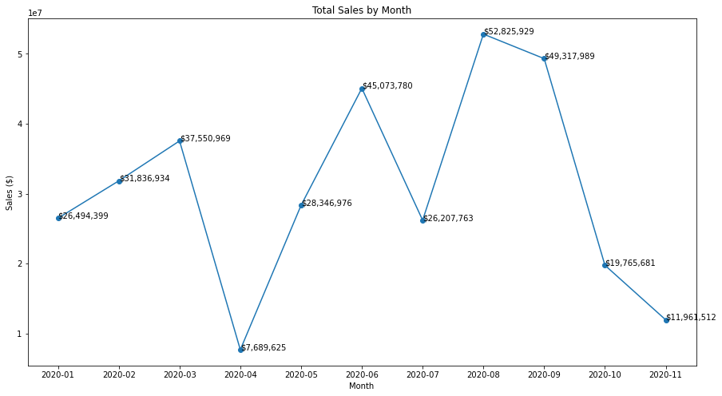

```python
df['month'] = df['event_time'].dt.strftime('%Y-%m')

# group the dataframe by month and sum the price column
sales_by_month = df.groupby('month')['price'].sum()

plt.plot(sales_by_month.index, sales_by_month.values, marker='o')

# add values to the markers
for x, y in zip(sales_by_month.index, sales_by_month.values):
    plt.text(x, y, f'${y:,.0f}')

plt.title('Total Sales by Month')
plt.xlabel('Month')
plt.ylabel('Sales ($)')
plt.show()
```

According to the graph above, this store grosses tens of millions of dollars in sales per month, despite having a few oscillations and swings, which are only natural given that consumers tend to have cyclical buying behavior. What's more, given these figures, we could infer that a potential solution for remarketing and increasing the number of repeat customers would be very beneficial for the company and could alone increase its gross revenue by a few million dollars.

However, we have to take into account that, despite having thousands of products available for purchase, probably only a few of these products contribute significantly to the revenue. So, let's find out which products, identified by their ID, contribute the most to the store's revenue.

[output not shown]

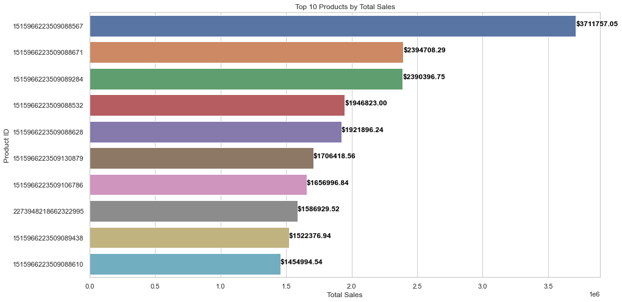

```python
# Group the dataframe by product_id and sum the sales
product_sales = df.groupby('product_id')['price'].sum().reset_index().astype({'product_id':'object'})

# Sort the products by sales in descending order and get the top 10
top_products = product_sales.sort_values('price', ascending=False).head(10)

# Create the bar chart using Seaborn
sns.set(style="whitegrid")
ax = sns.barplot(x="price", y=top_products["product_id"].astype('str'), data=top_products)

for i, v in enumerate(top_products['price']):
    ax.text(v + 100, i, "${:.2f}".format(v), color='black', fontweight='bold')

# Set the axis labels and title
ax.set(xlabel='Total Sales', ylabel='Product ID', title='Top 10 Products by Total Sales')
```

Now, the fact that the product IDs are anonymized makes it harder for us to gain practical insights and greatly reduces the explainability of the model. However, we can already see that some products have a bigger contribution to the store's revenue. Moving forward, let's also take some time to see how this breakdown plays out by the number of sales, rather than the gross revenue.

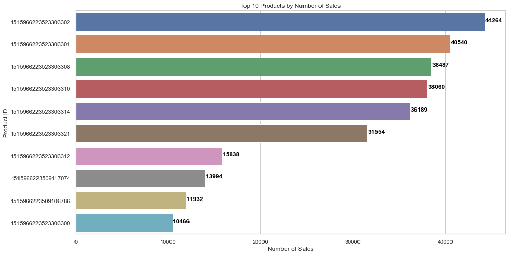

```python
# Count the number of occurrences of each product_id in the dataframe
product_counts = df['product_id'].value_counts().reset_index()
product_counts.columns = ['product_id', 'sales_count']

# Sort the products by sales count in descending order and get the top 10
top_products = product_counts.sort_values('sales_count', ascending=False).head(10)

# Create the bar chart using Seaborn
sns.set(style="whitegrid")
ax = sns.barplot(x="sales_count", y="product_id", data=top_products, orient="h", order=top_products['product_id'])

# Add sales count on top of the bars
for i, v in enumerate(top_products['sales_count']):
    ax.text(v + 50, i, str(v), color='black', fontweight='bold')

# Set the axis labels and title
ax.set(xlabel='Number of Sales', ylabel='Product ID', title='Top 10 Products by Number of Sales')

# Show the plot
plt.show()
```

Once again, we observe that some products make significantly more sales than others. Unfortunately, the anonymized encoding of the product IDs makes it harder for us to gain more specific insights into this pattern and hinders the explainability of the model. Later on, we will have to find ways to account for this fact, since the human-in-the-loop aspect is an important part of this business problem that cannot be ignored.

Now that we have gained some insights from the products themselves and the revenue metrics of this store, let's take some time to visually analyze the behavior of the customers. First, let's examine the distribution of customers by their number of purchases and see if we can draw any useful insights from it.

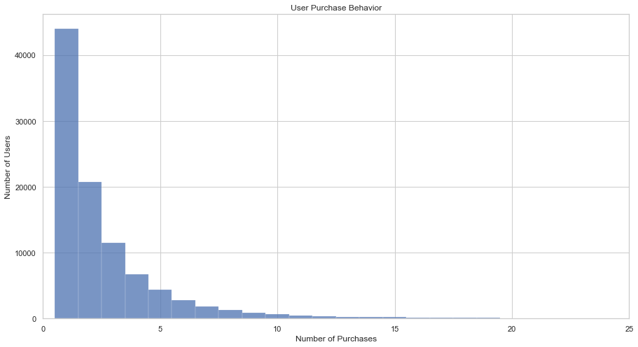

```python
# Group the data by user_id and count the number of purchases made by each user
user_purchases = df.groupby('user_id')['order_id'].nunique()

# Create a histogram of the number of purchases per user using Seaborn
sns.histplot(data=user_purchases, bins=2000, kde=False,discrete=True)

# Add axis labels and a title
plt.xlabel('Number of Purchases')
plt.ylabel('Number of Users')
plt.title('User Purchase Behavior')
plt.xlim(0,25)

# Display the histogram
plt.show()
```

Now, let's gather our last visual insight from this data and see the distribution of how much each user spends on the store. This information can be useful for crafting our data mining task and highlighting the importance of our project once more.

|  | price |
| --- | --- |
| count | 98244.000000 |
| mean | 1194.171707 |
| std | 3828.281133 |
| min | 0.000000 |
| 25% | 138.870000 |
| 50% | 432.450000 |
| 75% | 1092.580000 |
| max | 121701.300000 |

```
(0.0, 5000.0)
```

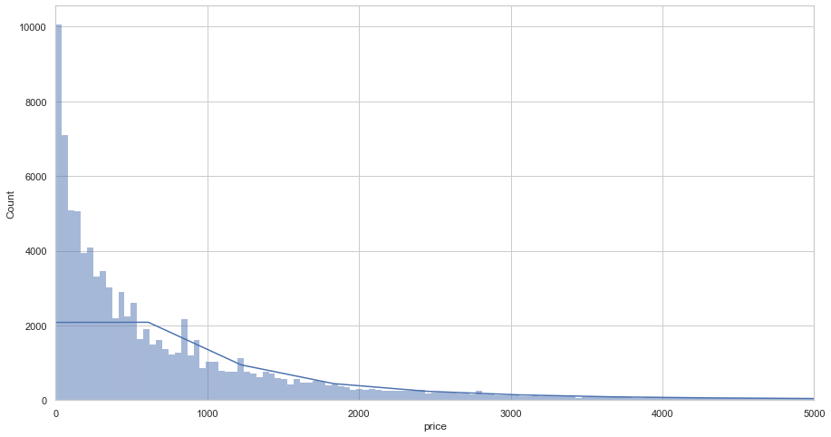

```python
# Calculate the total dollars spent by each user
user_spending = df.groupby('user_id')['price'].sum().reset_index()
display(user_spending[['price']].describe())

# Create a distribution plot using Seaborn
sns.histplot(user_spending, x="price", kde=True)
plt.xlim(0,5000)
```

All in all, this data exploration helped us gain a better understanding of this particular electronic ecommerce store, clarified the challenges we face, and identified a few particularities that will be useful for us in our subsequent data mining tasks.

# Association Pattern Mining

Association pattern mining is a data mining technique that involves discovering relationships or patterns among items in a dataset. Specifically, it identifies the co-occurrence of items and analyzes the strength of the relationship between them.

And, in the context of our project, we will use this data mining technique to identify items that are frequently purchased together and then create potential product recommendations to be marketed to the existing customer base via online ads.

As the online advertising landscape involves a human in the loop, often referred to as the media buyer, it is crucial to ensure explainability of the model. The rules and product recommendations generated by this data mining technique must be easy to explain to any non-technical stakeholder, otherwise, the insights gathered from it will be impractical and useless.

For this reason, the chosen data mining technique was the association rule mining with the Apriori algorithm, since its insights can easily be explained to non-technical stakeholders by using "if-then" rules (Brin et al., 1997).

Furthermore, in order to ensure that the model can be easily explained to the media buyer, this mining task will focus solely on generating association rules between categories (which are presented in a human-readable format in this dataset, unlike the product_ids which are encoded). Another advantage of this approach is that since there are fewer unique categories than unique products, the mining process will require way less computational resources and time.

On top of that, working with categories provides more general insights, allowing media buyers and other business stakeholders to have more flexibility in deciding which types of products to promote to their existing customer base based on their business goals.

In summary, this data mining technique aims to help us to understand the purchasing behavior of our customers better, and create targeted and effective data-driven product recommendations to drive sales and growth for the ecommerce store.

Now, for the sake of this project, we will only consider itemsets that have a minimum support of 0.01, meaning itemsets that appear at least 1% of the time in the entire dataset. Doing so will help us generate more meaningful and practical association rules while also saving computational resources. (Aggarwal & Sindhu, 2015)

```python
from mlxtend.frequent_patterns import apriori
from mlxtend.frequent_patterns import association_rules
from mlxtend.preprocessing import TransactionEncoder


# Preprocess the data to extract transaction data
transactions = df.dropna().groupby(['user_id'])['category_code'].apply(list).values.tolist()


# Convert transaction data from list to pandas DataFrame
te = TransactionEncoder()
te_ary = te.fit(transactions).transform(transactions)
te_df = pd.DataFrame(te_ary, columns=te.columns_)


# Generate frequent itemsets with a minimum support of 0.01
frequent_itemsets = apriori(te_df, min_support=0.01, use_colnames=True)
```

As we have emphasized repeatedly, interpretability of the model by humans is crucial, and therefore, we will use the lift association rule as our guiding metric. The lift can be easily interpreted by a potential media buyer as an "if-then" rule, such as: "if the antecedents of product A are purchased, then the consequents have a higher likelihood of being purchased as well."

And since ad space is costly and limited, a key constraint we have to consider in this project is maximizing the effectiveness of our product recommendations. To achieve this, we will only recommend products that have at least twice the likelihood of being purchased based on our association rule mining results. This will help us prioritize the most relevant and profitable products to promote to our existing customer base, while minimizing the cost and resources spent on ineffective ad campaigns.

```python
# Generate association rules with a minimum confidence of 0.5
rules = association_rules(frequent_itemsets, metric='lift', min_threshold=2)
rules.sort_values(by='lift',ascending=False)
```

|  | antecedents | consequents | antecedent support | consequent support | support | confidence | lift | leverage | conviction |
| --- | --- | --- | --- | --- | --- | --- | --- | --- | --- |
| 1609 | (appliances.kitchen.refrigerators, appliances.... | (appliances.kitchen.hood, appliances.kitchen.w... | 0.014992 | 0.016898 | 0.010266 | 0.684791 | 40.525407 | 0.010013 | 3.118886 |
| 1612 | (appliances.kitchen.hood, appliances.kitchen.w... | (appliances.kitchen.refrigerators, appliances.... | 0.016898 | 0.014992 | 0.010266 | 0.607562 | 40.525407 | 0.010013 | 2.509970 |
| 1608 | (appliances.kitchen.refrigerators, appliances.... | (appliances.kitchen.oven, appliances.kitchen.w... | 0.019971 | 0.013075 | 0.010266 | 0.514065 | 39.315369 | 0.010005 | 2.030981 |
| 1613 | (appliances.kitchen.oven, appliances.kitchen.w... | (appliances.kitchen.refrigerators, appliances.... | 0.013075 | 0.019971 | 0.010266 | 0.785173 | 39.315369 | 0.010005 | 4.561938 |
| 1616 | (appliances.kitchen.oven) | (appliances.kitchen.refrigerators, appliances.... | 0.027098 | 0.013813 | 0.010266 | 0.378862 | 27.426995 | 0.009892 | 1.587709 |
| ... | ... | ... | ... | ... | ... | ... | ... | ... | ... |
| 1346 | (appliances.kitchen.kettle, appliances.kitchen... | (electronics.smartphone) | 0.010916 | 0.462487 | 0.010123 | 0.927346 | 2.005131 | 0.005075 | 7.398274 |
| 1397 | (electronics.smartphone) | (appliances.kitchen.kettle, appliances.environ... | 0.462487 | 0.011203 | 0.010388 | 0.022460 | 2.004895 | 0.005206 | 1.011516 |
| 1388 | (appliances.kitchen.kettle, appliances.environ... | (electronics.smartphone) | 0.011203 | 0.462487 | 0.010388 | 0.927237 | 2.004895 | 0.005206 | 7.387177 |
| 1737 | (appliances.kitchen.kettle, computers.notebook... | (electronics.smartphone) | 0.011093 | 0.462487 | 0.010277 | 0.926514 | 2.003332 | 0.005147 | 7.314540 |
| 1748 | (electronics.smartphone) | (appliances.kitchen.kettle, computers.notebook... | 0.462487 | 0.011093 | 0.010277 | 0.022222 | 2.003332 | 0.005147 | 1.011383 |

2060 rows × 9 columns

And those are the product categories that match our criteria for association rules. As you can see, we have 2060 potential product category recommendations. But now, let's put our approach to test and examine how it might perform in a real-life scenario.

# Evaluating

Of course, evaluating the data mining algorithm we have just created is of utmost importance; after all, while it has the potential to generate a lot of orders for the company, it could potentially cost thousands of dollars if it goes wrong.

Now, since evaluating data mining tasks is not straightforward, we will follow the approach outlined by Aggarwal (2015). That is, we will transform the insights we gathered from the Apriori algorithm into a small and simple recommender system, which will work as a classification model to predict whether a customer is likely to make a purchase or not. But, before we can define this problem as a binary classification problem and choose a suitable metric to evaluate it, we must first get clear on the constraints of this project that we have to work with.

First off, since this recommender system would potentially be used by a media buyer – someone with no data science skills – we will aim for explainability of the model above all else.

What's more, since this is a binary classification problem, 0 will be assigned in the case of a customer who has not bought any products on the recommended category, and 1 will be assigned if the customer bought a product in the recommended category. The data used to train the model will be all of the data from before September, and the testing set will be data starting from September.

Finally, to evaluate the accuracy of the model, we will take a look at the precision, recall and F1-score, since these measures can be closely related to the return on investment (ROI) of an advertisement campaign.

Of course, force-fitting a classification task into a data mining task is not always easy and straightforward and comes with its own set of limitations, which will be discussed later in this notebook. Having said that, let us now create our recommendations engine:

```python
# Preprocess the data to extract transaction data
train_df = df.query('event_time < "2020-09-01"').dropna().groupby(['user_id'])['category_code'].apply(list)

# Load test data
test_df = df.query('event_time >= "2020-09-01"').dropna().groupby(['user_id'])['category_code'].apply(list)

# Combine train and test data
data_df = pd.concat([train_df, test_df], axis=0).values.tolist()

# Encode data using TransactionEncoder
te = TransactionEncoder()
te_ary = te.fit(data_df).transform(data_df)
data_df = pd.DataFrame(te_ary, columns=te.columns_)

# Split data back into train and test
train_df = data_df.iloc[:len(train_df), :]
test_df = data_df.iloc[len(train_df):, :]

# Generate frequent itemsets
frequent_itemsets = apriori(train_df, min_support=0.01, use_colnames=True)

# Generate association rules
rules = association_rules(frequent_itemsets, metric="lift", min_threshold=1)

# Filter rules
rules = rules[(rules['lift'] >= 2) & (rules['confidence'] >= 0.3)]

# Sort rules
rules = rules.sort_values(by=['lift', 'confidence'], ascending=False)


# Make recommendations for each user in test data
recommendations = []
for index, row in test_df.iterrows():
    user_items = row[row==True].index
    recommended_items = []
    for _, r in rules.iterrows():
        if set(r['antecedents']).issubset(set(user_items)):
            recommended_items.extend(list(r['consequents']))
    recommendations.append(recommended_items)


print(recommendations[1:10])
```

```
[['appliances.kitchen.washer', 'appliances.kitchen.refrigerators', 'electronics.audio.headphone', 'computers.notebook', 'computers.notebook'], ['appliances.kitchen.washer', 'electronics.video.tv', 'computers.notebook'], ['appliances.kitchen.refrigerators', 'electronics.video.tv', 'appliances.kitchen…
```

As we can see, the recommendations made by the engine are easily interpretable and readable by humans, which means that it has passed the test of interpretability for the media buyer, who will now be able to act upon these recommendations, choose a suitable product, and begin retargeting customers with specific product recommendations.

However, we must also assess the accuracy of this model, since - more than explainability - effectiveness and return on investment are the key metrics for determining success in marketing campaigns. To do this, we will take a look at three highly used accuracy score metrics:

Precision: Measures the percentage of correctly predicted positive cases out of all the positive cases predicted. In the context of our project precision is important because it assess how accurately the ads are shown to the customers who are most likely to make a purchase.

Recall: Measures the percentage of true positive cases (i.e., correctly identified purchasers) out of all the actual positive cases. In our context, it would measure how many of the actual purchases were correctly identified by the model.

F1-score: Measured as the harmonic mean of precision and recall, thus providing a single score that summarizes the balance between the two metrics.

```python
def f1_score(y_true, y_pred):
    tp = 0
    fp = 0
    fn = 0
    for i in range(len(y_true)):
        tp += len(set(y_true[i]).intersection(set(y_pred[i])))
        fp += len(set(y_pred[i])) - len(set(y_true[i]).intersection(set(y_pred[i])))
        fn += len(set(y_true[i])) - len(set(y_true[i]).intersection(set(y_pred[i])))
    precision = tp / (tp + fp)
    recall = tp / (tp + fn)
    f1 = 2 * precision * recall / (precision + recall)
    return precision, recall, f1

# Compute F1 score
test_users = test_df.apply(lambda x: list(x[x==True].index), axis=1)
precision, recall, f1 = f1_score(test_users.values, recommendations)

print(f'Precision: {precision}\nRecall: {recall}\nF1: {f1}')
```

```
Precision: 0.3369621835607876
Recall: 0.08384312302348489
F1: 0.13427569172011541
```

As we can see, all of the models scored fairly poorly on the three metrics. However, we do not have enough information to say with precision if this model would be useful in an ads targeting use case. After all, the profitability of an ads campaign is highly dependent on the cost of advertisement and on the margin of the products sold. So, even with a fairly low rate of true positives, a particular campaign could be profitable depending on these two other variables (Both of which would have to be optimized by the media buyer).

On top of that, it is worth noting that - as we currently modelled this system - this binary classification model was evaluated by its capacity to predict if a customer ended up buying a given product category on their own or not. In order words, (as it is right now) it simply acted as a predictor (since recommendations didn't influence customer behavior in the testing set), and these evaluation metrics represent that.

Therefore, if such a recommender system was to be implemented to make real-time recommendations, we would expect its accuracy scores to increase, and therefore they would have to be closely monitored. After all, marketing recommended products to these customers on an ad platform will most likely drive their behavior in the direction of buying said items, thus driving accuracy metrics upwards.

Lastly, another great improvement that could be made to the model is to make predictions and recommendations based on particular items (instead of broad categories) and set a minimum threshold for their price-tag. After all, since online ads targeting is costly, prices have to be recouped fast. And even if the product recommendations are not very accurate, a high-ticket sale can easily recoup losses caused by bad recommendations and ultimately make the model profitable for the business.

All in all, given that the model has ample room for improvement, the business has ample room to increase the number of repeat orders by customers, and that low to mild accuracy is already enough for the model to be profitable (of course, provided that the recommended products have high margins) this recommender prototype based on insights gathered by the data mining process could be worth deploying in a real use case scenario.

# References

- Aggarwal, C. C. (2015). Data mining: the textbook (Vol. 1). New York: springer.
- Aggarwal, S., & Sindhu, R. (2015). An approach to improve the efficiency of apriori algorithm (No. e1410). PeerJ PrePrints.
- Brin, S., Motwani, R., Ullman, J. D., & Tsur, S. (1997, June). Dynamic itemset counting and implication rules for market basket data. In Proceedings of the 1997 ACM SIGMOD international conference on Management of data (pp. 255-264).
- Reichheld, F. F., & Schefter, P. (2000). E-loyalty: your secret weapon on the web. Harvard business review, 78(4), 105-113.